# Federal Reserve 0.75% Interest Rate Hike Announcement

2025-07-14

On June 15, 2022, the Federal Reserve raised interest rates by 0.75%, the highest rate hike since 1994, while indicating that another rate hike of 0.75% is possible. However, Chair of the Federal Reserve also stated that such high interest rate increases would not be a common move in the future, reducing uncertainty in markets.

```r
library("tidyquant")
```

```r
library("zoo")
library("ggplot2")
library("tidyverse")
library("caret")
#library('dplyr')
library("corrplot")
```

## Time Series’ for Federal Reserve 2022 0.75% Rate Hike

Below are the daily time series for the stock prices from the selected GICS sector companies.

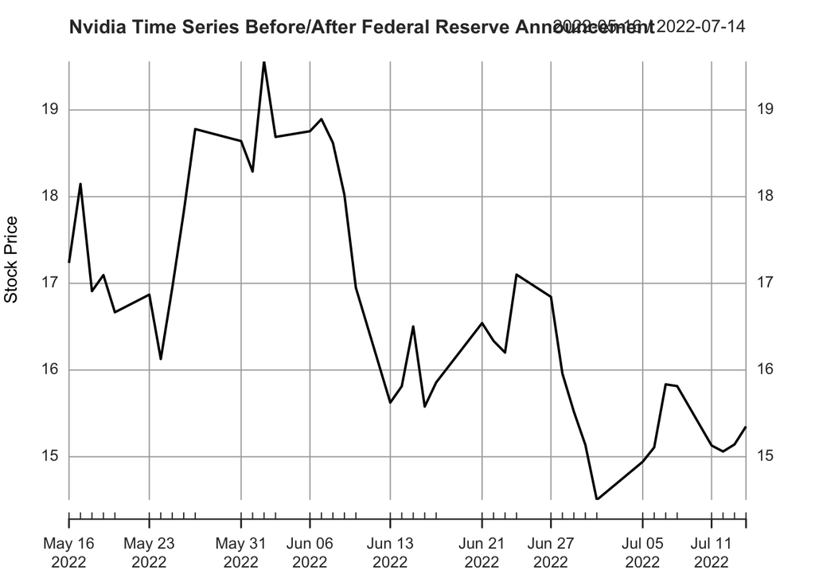

```r
##Nvidia
nvda_data<-tq_get("NVDA",get="stock.prices",complete_cases=TRUE,from="2022-05-15",to="2022-07-15")
xts_nvda<-xts(nvda_data$adjusted,order.by=nvda_data$date)
plot(xts_nvda,main="Nvidia Time Series Before/After Federal Reserve Announcement",xlab="Date",ylab="Stock Price")
```

```r
nvda_data
```

```
## # A tibble: 41 × 8
##    symbol date        open  high   low close    volume adjusted
##    <chr>  <date>     <dbl> <dbl> <dbl> <dbl>     <dbl>    <dbl>
##  1 NVDA   2022-05-16  17.5  17.8  17.1  17.3 521446000     17.2
##  2 NVDA   2022-05-17  18.1  18.4  17.6  18.2 585830000     18.1
##  3 NVDA   2022-05-18  17.7  18.1  16.9  16.9 545161000     16.9
##  4 NVDA   2022-05-19  16.9  17.7  16.7  17.1 621310000     17.1
##  5 NVDA   2022-05-20  17.3  17.4  15.8  16.7 739105000     16.7
##  6 NVDA   2022-05-23  16.3  16.9  16.2  16.9 639889000     16.9
##  7 NVDA   2022-05-24  16.5  16.6  15.8  16.2 588550000     16.1
##  8 NVDA   2022-05-25  16.0  17.1  16    17.0 781132000     16.9
##  9 NVDA   2022-05-26  16.0  18.1  16.0  17.9 996575000     17.8
## 10 NVDA   2022-05-27  18.2  18.9  18.1  18.8 738379000     18.8
## # ℹ 31 more rows
```

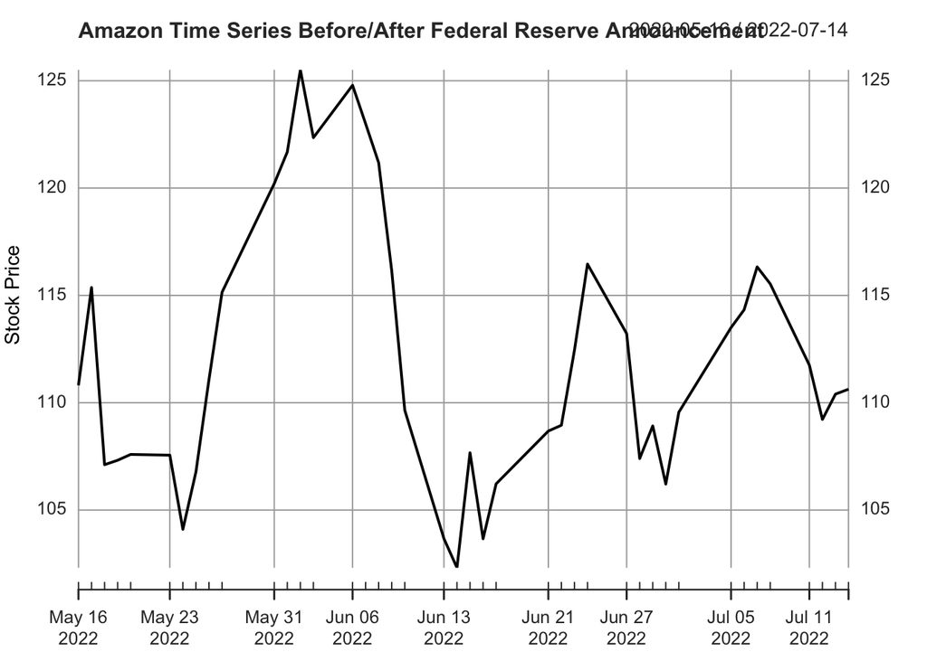

```r
##Amazon
amzn_data<-tq_get("AMZN",get="stock.prices",complete_cases=TRUE,from="2022-05-15",to="2022-07-15")
xts_amzn<-xts(amzn_data$adjusted,order.by=amzn_data$date)
plot(xts_amzn,main="Amazon Time Series Before/After Federal Reserve Announcement",xlab="Date",ylab="Stock Price")
```

```r
amzn_data
```

```
## # A tibble: 41 × 8
##    symbol date        open  high   low close    volume adjusted
##    <chr>  <date>     <dbl> <dbl> <dbl> <dbl>     <dbl>    <dbl>
##  1 AMZN   2022-05-16  113.  114.  110.  111.  74566000     111.
##  2 AMZN   2022-05-17  113.  116.  111.  115.  76448000     115.
##  3 AMZN   2022-05-18  111.  113.  106.  107. 108380000     107.
##  4 AMZN   2022-05-19  106.  110.  106.  107.  88142000     107.
##  5 AMZN   2022-05-20  110.  110.  105.  108.  99500000     108.
##  6 AMZN   2022-05-23  108.  109.  104.  108. 107798000     108.
##  7 AMZN   2022-05-24  104.  105.  101.  104. 102934000     104.
##  8 AMZN   2022-05-25  104.  108.  104.  107.  93120000     107.
##  9 AMZN   2022-05-26  108.  113.  107.  111.  93002000     111.
## 10 AMZN   2022-05-27  114.  115.  113.  115.  93660000     115.
## # ℹ 31 more rows
```

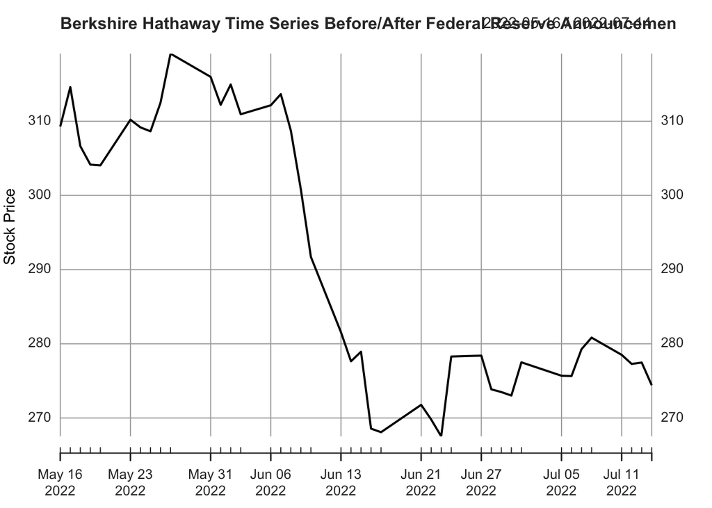

```r
##Berkshire Hathaway
brkb_data<-tq_get("BRK-B",get="stock.prices",complete_cases=TRUE,from="2022-05-15",to="2022-07-15")
xts_brkb<-xts(brkb_data$adjusted,order.by=brkb_data$date)
plot(xts_brkb,main="Berkshire Hathaway Time Series Before/After Federal Reserve Announcement",xlab="Date",ylab="Stock Price")
```

```r
brkb_data
```

```
## # A tibble: 41 × 8
##    symbol date        open  high   low close  volume adjusted
##    <chr>  <date>     <dbl> <dbl> <dbl> <dbl>   <dbl>    <dbl>
##  1 BRK-B  2022-05-16  310.  312.  307.  309. 3697600     309.
##  2 BRK-B  2022-05-17  315.  315.  312.  315. 4154200     315.
##  3 BRK-B  2022-05-18  313.  314.  306.  307. 4417900     307.
##  4 BRK-B  2022-05-19  304.  306.  301.  304. 4730100     304.
##  5 BRK-B  2022-05-20  307.  307.  298.  304. 5517600     304.
##  6 BRK-B  2022-05-23  307.  312.  307.  310. 4142100     310.
##  7 BRK-B  2022-05-24  309.  310.  304.  309. 3657600     309.
##  8 BRK-B  2022-05-25  309.  311.  306.  309. 3704800     309.
##  9 BRK-B  2022-05-26  311.  314.  311.  312. 4472000     312.
## 10 BRK-B  2022-05-27  315.  319.  314.  319. 4280100     319.
## # ℹ 31 more rows
```

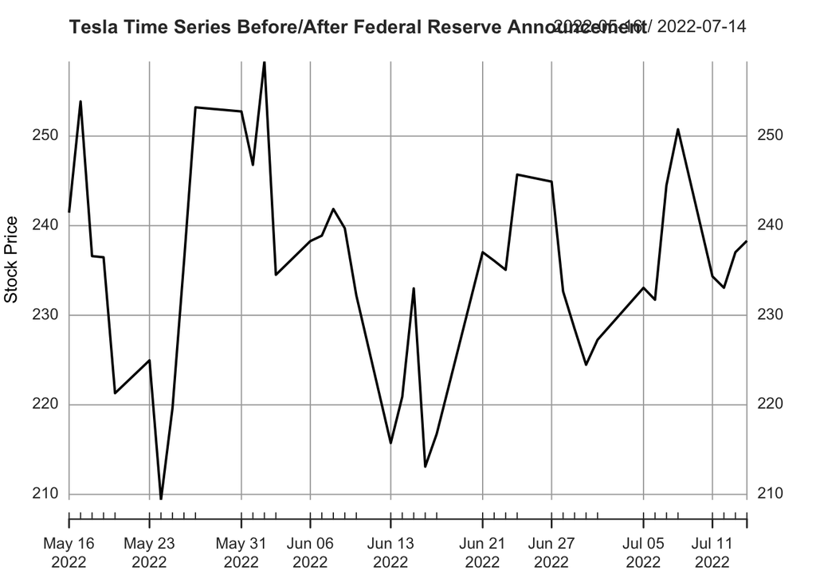

```r
##Tesla
tsla_data<-tq_get("TSLA",get="stock.prices",complete_cases=TRUE,from="2022-05-15",to="2022-07-15")
xts_tsla<-xts(tsla_data$adjusted,order.by=tsla_data$date)
plot(xts_tsla,main="Tesla Time Series Before/After Federal Reserve Announcement",xlab="Date",ylab="Stock Price")
```

```r
tsla_data
```

```
## # A tibble: 41 × 8
##    symbol date        open  high   low close    volume adjusted
##    <chr>  <date>     <dbl> <dbl> <dbl> <dbl>     <dbl>    <dbl>
##  1 TSLA   2022-05-16  256.  257.  240.  241.  86098500     241.
##  2 TSLA   2022-05-17  249.  255.  243.  254.  80236200     254.
##  3 TSLA   2022-05-18  248.  254.  234.  237.  87811800     237.
##  4 TSLA   2022-05-19  236.  245.  231.  236.  90296700     236.
##  5 TSLA   2022-05-20  238.  241.  211   221. 144973200     221.
##  6 TSLA   2022-05-23  218.  227.  213.  225.  88903500     225.
##  7 TSLA   2022-05-24  218.  218.  207.  209.  89092500     209.
##  8 TSLA   2022-05-25  208.  223.  208.  220.  92139300     220.
##  9 TSLA   2022-05-26  220.  240.  218.  236. 106003200     236.
## 10 TSLA   2022-05-27  241.  253.  240.  253.  89295000     253.
## # ℹ 31 more rows
```

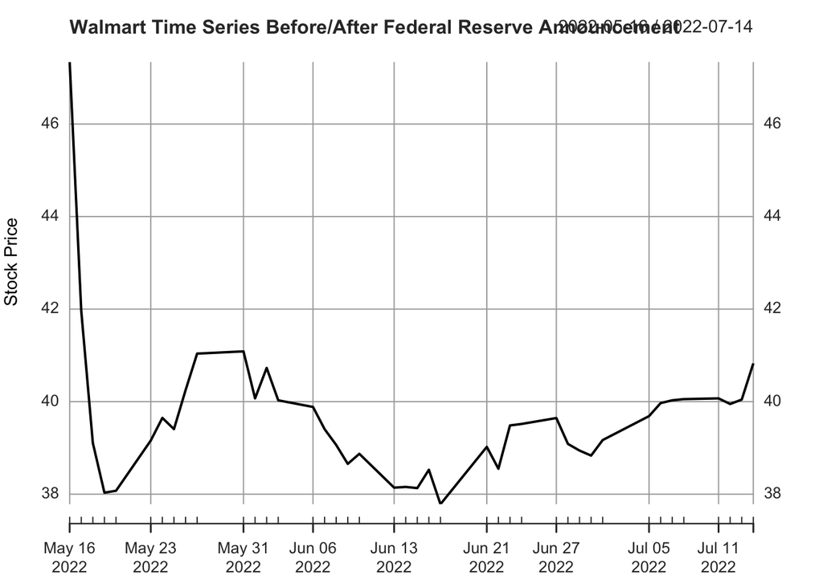

```r
##Walmart
wmt_data<-tq_get("WMT",get="stock.prices",complete_cases=TRUE,from="2022-05-15",to="2022-07-15")
xts_wmt<-xts(wmt_data$adjusted,order.by=tsla_data$date)
plot(xts_wmt,main="Walmart Time Series Before/After Federal Reserve Announcement",xlab="Date",ylab="Stock Price")
```

```r
wmt_data
```

```
## # A tibble: 41 × 8
##    symbol date        open  high   low close    volume adjusted
##    <chr>  <date>     <dbl> <dbl> <dbl> <dbl>     <dbl>    <dbl>
##  1 WMT    2022-05-16  49.8  49.9  48.8  49.4  21449100     47.3
##  2 WMT    2022-05-17  45.5  45.8  43.5  43.8 132940200     42.0
##  3 WMT    2022-05-18  42.7  42.8  40.5  40.8 104253000     39.1
##  4 WMT    2022-05-19  40.3  40.6  39.5  39.7  71008500     38.0
##  5 WMT    2022-05-20  39.9  40.3  39.1  39.7  49356000     38.1
##  6 WMT    2022-05-23  40.0  41.3  40.0  40.9  43680900     39.2
##  7 WMT    2022-05-24  40.4  41.5  40.4  41.4  34584900     39.6
##  8 WMT    2022-05-25  41.3  41.6  40.9  41.1  27121800     39.4
##  9 WMT    2022-05-26  41.8  42.1  41.5  42    28197600     40.2
## 10 WMT    2022-05-27  41.8  42.9  41.8  42.8  25299900     41.0
## # ℹ 31 more rows
```

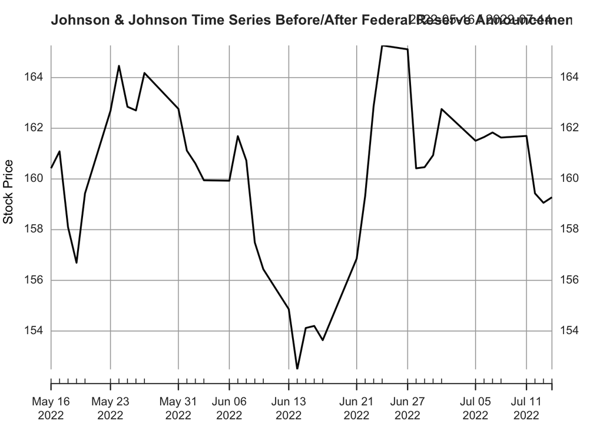

```r
##Johnson & Johnson
jnj_data<-tq_get("JNJ",get="stock.prices",complete_cases=TRUE,from="2022-05-15",to="2022-07-15")
xts_jnj<-xts(jnj_data$adjusted,order.by=tsla_data$date)
plot(xts_jnj,main="Johnson & Johnson Time Series Before/After Federal Reserve Announcement",xlab="Date",ylab="Stock Price")
```

```r
jnj_data
```

```
## # A tibble: 41 × 8
##    symbol date        open  high   low close  volume adjusted
##    <chr>  <date>     <dbl> <dbl> <dbl> <dbl>   <dbl>    <dbl>
##  1 JNJ    2022-05-16  177.  179.  176.  178. 5516700     160.
##  2 JNJ    2022-05-17  179.  180.  177.  179. 5751100     161.
##  3 JNJ    2022-05-18  179.  179.  175.  176. 8608800     158.
##  4 JNJ    2022-05-19  175.  175.  173.  174. 6874500     157.
##  5 JNJ    2022-05-20  175.  177.  174.  177. 7522100     159.
##  6 JNJ    2022-05-23  178.  180.  177.  179. 7040800     163.
##  7 JNJ    2022-05-24  179.  182.  179.  181. 6419800     164.
##  8 JNJ    2022-05-25  181.  182.  179.  180. 6558900     163.
##  9 JNJ    2022-05-26  181   181   179.  179. 6897600     163.
## 10 JNJ    2022-05-27  180.  181.  178.  181. 5853600     164.
## # ℹ 31 more rows
```

## Analysis of Time Series

Excluding Walmart, all stocks experienced an increase in price on the day of the Federal Reserve announcement. Walmart’s price declined by around 0.02 USD. In addition to the interest rate hike, the Federal Reserve also mentioned that future rate hikes will not be as large. Higher interest rates discourages borrowing and reduces consumer spending, which can allow leisure spending to vastly decline as a result of tight budgets. Nvidia, Amazon, Tesla, and Berkshire Hathaway are all companies that people can spend on for a considerable amount of leisure, which puts their profit at great risk of declining. However, Walmart and Johnson & Johnson provide much more essential products and services, thus allowing for their profits to be at less risk of declining, reducing uncertainty on their market valuations. It is also important to note that throughout the months of May and June 2022, the United States experienced the highest inflation rates in over 40 years of 8.6% and 9.1% respectively. The economic conditions at the time could have also played a leading role in the swinging or declining stock prices observed in Nvidia, Amazon, Berkshire Hathaway, and Tesla as high inflation cast more doubt on consumer spending. Such phenomenon can be observed in the days leading to the Federal Reserve announcement. On June 10, 2022, the U.S. Bureau of Labor Statistics revealed that the inflation rate had reach 8.6%, which was at that time, the highest seen since 1981. Despite the uncertainty brought by inflation and high interest rates, stock prices increased on the day of the announcement. This observation can be attributed to the previous suggestion from analyzing Liberation Day. Reducing economic uncertainty has a greater impact on market valuations than increasing it. Even though high interest rates introduce uncertainty, the assurance that future rate hikes will not be as high may have a greater effect on markets. In addition, higher interest rates can show the initiative to counter inflation, which can also reduce uncertainty in some ways and make the future of the economy more predictable.

## Cross Validation for Time Series Trend Decomposition for Federal Reserve 2022 0.75% Rate Hike

```r
set.seed(100)

##Nvidia
nvda_train<-trainControl(method="timeslice",initialWindow=33,horizon=5)
nvda_grid_vals<-expand.grid(span=seq(from=0.1,to=0.9,by=0.01),degree=1)
nvda_data$date_times<-as.numeric(nvda_data$date)
nvda_cv<-suppressWarnings(train(adjusted~date_times,data=nvda_data,method="gamLoess",tuneGrid=nvda_grid_vals,
                                trControl=nvda_train))
nvda_optimal_span<-nvda_cv$results|>slice_min(RMSE,with_ties=FALSE)|>pull(span)

##Amazon
amzn_train<-trainControl(method="timeslice",initialWindow=33,horizon=5)
amzn_grid_vals<-expand.grid(span=seq(from=0.1,to=0.9,by=0.01),degree=1)
amzn_data$date_times<-as.numeric(amzn_data$date)
amzn_cv<-suppressWarnings(train(adjusted~date_times,data=amzn_data,method="gamLoess",tuneGrid=amzn_grid_vals,
                                trControl=amzn_train))
amzn_optimal_span<-amzn_cv$results|>slice_min(RMSE,with_ties=FALSE)|>pull(span)

##Berkshire Hathaway
brkb_train<-trainControl(method="timeslice",initialWindow=33,horizon=5)
brkb_grid_vals<-expand.grid(span=seq(from=0.1,to=0.9,by=0.01),degree=1)
brkb_data$date_times<-as.numeric(brkb_data$date)
brkb_cv<-suppressWarnings(train(adjusted~date_times,data=brkb_data,method="gamLoess",tuneGrid=brkb_grid_vals,
                                trControl=brkb_train))
brkb_optimal_span<-brkb_cv$results|>slice_min(RMSE,with_ties=FALSE)|>pull(span)

##Tesla
tsla_train<-trainControl(method="timeslice",initialWindow=33,horizon=5)
tsla_grid_vals<-expand.grid(span=seq(from=0.1,to=0.9,by=0.01),degree=1)
tsla_data$date_times<-as.numeric(tsla_data$date)
tsla_cv<-suppressWarnings(train(adjusted~date_times,data=tsla_data,method="gamLoess",tuneGrid=tsla_grid_vals,
                                trControl=tsla_train))
tsla_optimal_span<-tsla_cv$results|>slice_min(RMSE,with_ties=FALSE)|>pull(span)

##Walmart
wmt_train<-trainControl(method="timeslice",initialWindow=33,horizon=5)
wmt_grid_vals<-expand.grid(span=seq(from=0.1,to=0.9,by=0.01),degree=1)
wmt_data$date_times<-as.numeric(wmt_data$date)
wmt_cv<-suppressWarnings(train(adjusted~date_times,data=wmt_data,method="gamLoess",tuneGrid=wmt_grid_vals,
                               trControl=wmt_train))
wmt_optimal_span<-wmt_cv$results|>slice_min(RMSE,with_ties=FALSE)|>pull(span)

##Johnson & Johnson
jnj_train<-trainControl(method="timeslice",initialWindow=33,horizon=5)
jnj_grid_vals<-expand.grid(span=seq(from=0.1,to=0.9,by=0.01),degree=1)
jnj_data$date_times<-as.numeric(jnj_data$date)
jnj_cv<-suppressWarnings(train(adjusted~date_times,data=jnj_data,method="gamLoess",tuneGrid=jnj_grid_vals,
                               trControl=jnj_train))
jnj_optimal_span<-jnj_cv$results|>slice_min(RMSE,with_ties=FALSE)|>pull(span)
nvda_optimal_span
```

```
## [1] 0.61
```

```r
amzn_optimal_span
```

```
## [1] 0.61
```

```r
brkb_optimal_span
```

```
## [1] 0.43
```

```r
tsla_optimal_span
```

```
## [1] 0.61
```

```r
wmt_optimal_span
```

```
## [1] 0.58
```

```r
jnj_optimal_span
```

```
## [1] 0.85
```

## Time Series Decomposition (Trend & Residual)

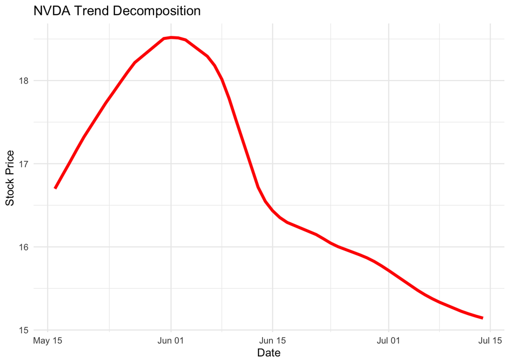

```r
##Nvidia
loess_nvda<-loess(adjusted~as.numeric(date),data=nvda_data,span=nvda_optimal_span)
smooth_nvda<-predict(loess_nvda)
trend_decomp_nvda_plot<-nvda_data|>ggplot(aes(x=date))+geom_line(aes(y=smooth_nvda),color="red",linewidth=1.4)+
                                   labs(title="NVDA Trend Decomposition",x="Date",y="Stock Price") +
                                   theme_minimal()
trend_decomp_nvda_plot
```

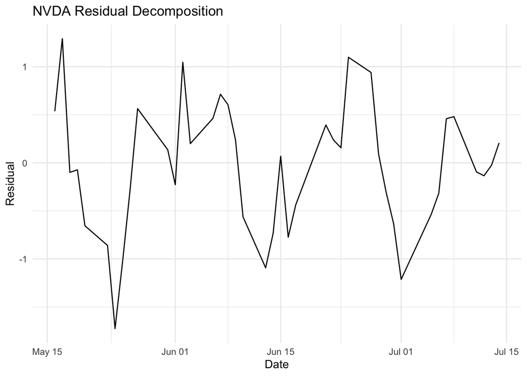

```r
nvda_data$residual_decomp<-residuals(loess_nvda)
residual_decomp_nvda_plot<-nvda_data|>ggplot(aes(x=date,y=residual_decomp))+geom_line() +
                                      labs(title="NVDA Residual Decomposition",x="Date",y="Residual") +
                                      theme_minimal()
residual_decomp_nvda_plot
```

```r
nvda_data
```

```
## # A tibble: 41 × 10
##    symbol date        open  high   low close    volume adjusted date_times
##    <chr>  <date>     <dbl> <dbl> <dbl> <dbl>     <dbl>    <dbl>      <dbl>
##  1 NVDA   2022-05-16  17.5  17.8  17.1  17.3 521446000     17.2      19128
##  2 NVDA   2022-05-17  18.1  18.4  17.6  18.2 585830000     18.1      19129
##  3 NVDA   2022-05-18  17.7  18.1  16.9  16.9 545161000     16.9      19130
##  4 NVDA   2022-05-19  16.9  17.7  16.7  17.1 621310000     17.1      19131
##  5 NVDA   2022-05-20  17.3  17.4  15.8  16.7 739105000     16.7      19132
##  6 NVDA   2022-05-23  16.3  16.9  16.2  16.9 639889000     16.9      19135
##  7 NVDA   2022-05-24  16.5  16.6  15.8  16.2 588550000     16.1      19136
##  8 NVDA   2022-05-25  16.0  17.1  16    17.0 781132000     16.9      19137
##  9 NVDA   2022-05-26  16.0  18.1  16.0  17.9 996575000     17.8      19138
## 10 NVDA   2022-05-27  18.2  18.9  18.1  18.8 738379000     18.8      19139
## # ℹ 31 more rows
## # ℹ 1 more variable: residual_decomp <dbl>
```

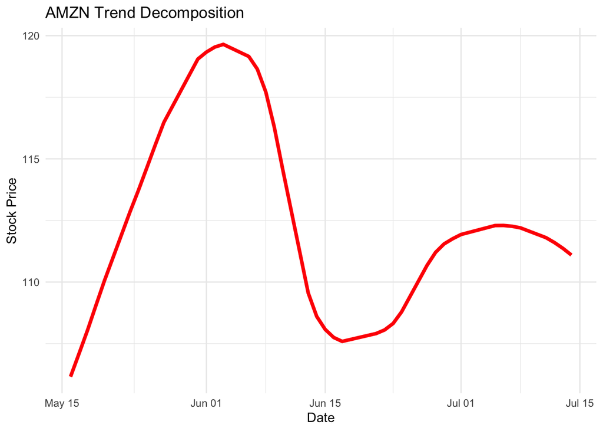

```r
##Amazon
loess_amzn<-loess(adjusted~as.numeric(date),data=amzn_data,span=amzn_optimal_span)
smooth_amzn<-predict(loess_amzn)
trend_decomp_amzn_plot<-amzn_data|>ggplot(aes(x=date))+geom_line(aes(y=smooth_amzn),color="red",linewidth=1.4) +
                                   labs(title="AMZN Trend Decomposition",x="Date",y="Stock Price") +
                                   theme_minimal()
trend_decomp_amzn_plot
```

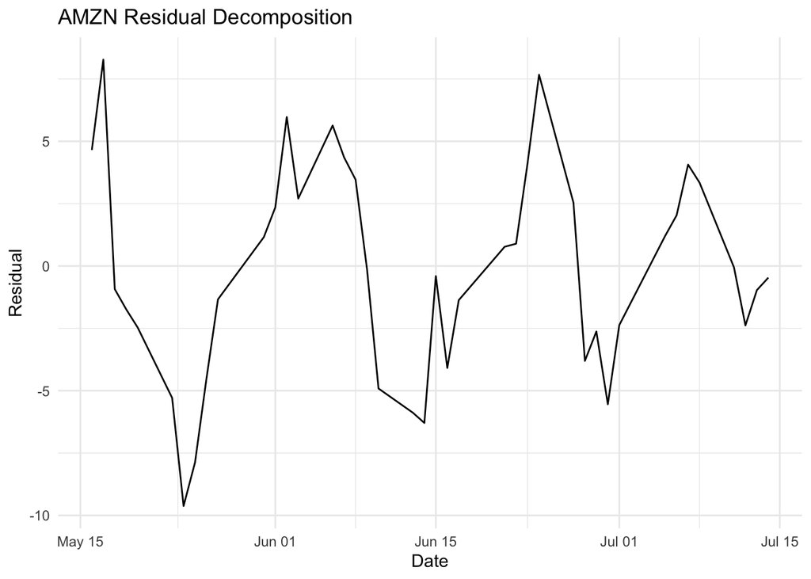

```r
amzn_data$residual_decomp<-residuals(loess_amzn)
residual_decomp_amzn_plot<-amzn_data|>ggplot(aes(x=date,y=residual_decomp))+geom_line() +
                                      labs(title="AMZN Residual Decomposition",x="Date",y="Residual") +
                                      theme_minimal()
residual_decomp_amzn_plot
```

```r
amzn_data
```

```
## # A tibble: 41 × 10
##    symbol date        open  high   low close    volume adjusted date_times
##    <chr>  <date>     <dbl> <dbl> <dbl> <dbl>     <dbl>    <dbl>      <dbl>
##  1 AMZN   2022-05-16  113.  114.  110.  111.  74566000     111.      19128
##  2 AMZN   2022-05-17  113.  116.  111.  115.  76448000     115.      19129
##  3 AMZN   2022-05-18  111.  113.  106.  107. 108380000     107.      19130
##  4 AMZN   2022-05-19  106.  110.  106.  107.  88142000     107.      19131
##  5 AMZN   2022-05-20  110.  110.  105.  108.  99500000     108.      19132
##  6 AMZN   2022-05-23  108.  109.  104.  108. 107798000     108.      19135
##  7 AMZN   2022-05-24  104.  105.  101.  104. 102934000     104.      19136
##  8 AMZN   2022-05-25  104.  108.  104.  107.  93120000     107.      19137
##  9 AMZN   2022-05-26  108.  113.  107.  111.  93002000     111.      19138
## 10 AMZN   2022-05-27  114.  115.  113.  115.  93660000     115.      19139
## # ℹ 31 more rows
## # ℹ 1 more variable: residual_decomp <dbl>
```

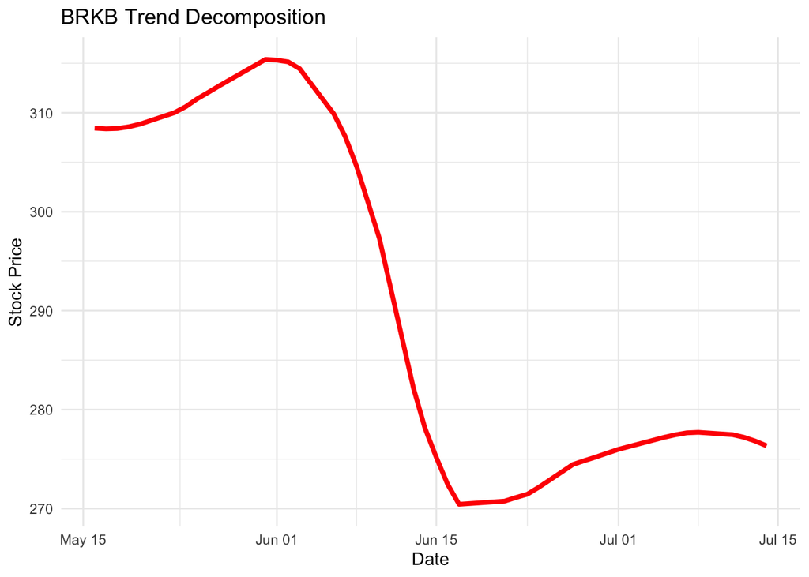

```r
##Berkshire Hathaway
loess_brkb<-loess(adjusted~as.numeric(date),data=brkb_data,span=brkb_optimal_span)
smooth_brkb<-predict(loess_brkb)
trend_decomp_brkb_plot<-brkb_data|>ggplot(aes(x=date))+geom_line(aes(y=smooth_brkb),color="red",linewidth=1.4) +
                                   labs(title="BRKB Trend Decomposition",x="Date",y="Stock Price") +
                                   theme_minimal()
trend_decomp_brkb_plot
```

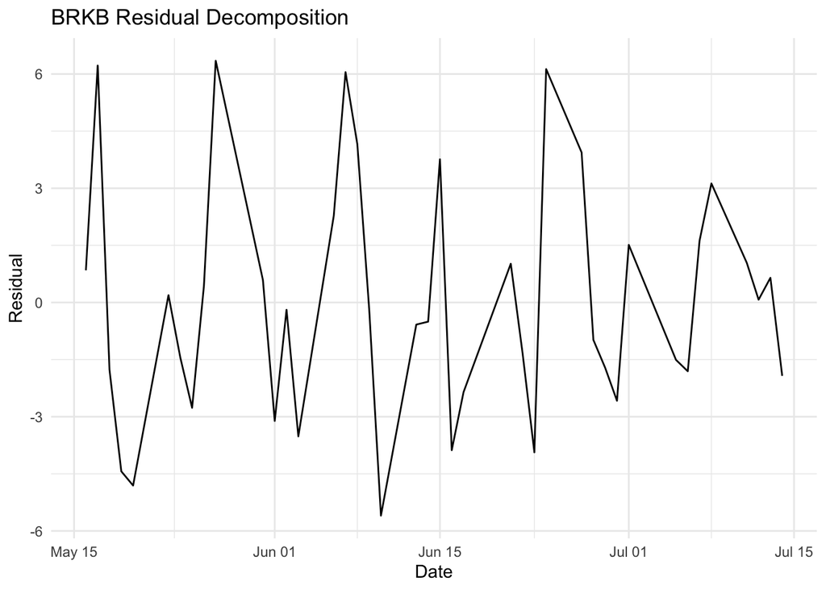

```r
brkb_data$residual_decomp<-residuals(loess_brkb)
residual_decomp_brkb_plot<-brkb_data|>ggplot(aes(x=date,y=residual_decomp))+geom_line() +
                                      labs(title="BRKB Residual Decomposition",x="Date",y="Residual") +
                                      theme_minimal()
residual_decomp_brkb_plot
```

```r
brkb_data
```

```
## # A tibble: 41 × 10
##    symbol date        open  high   low close  volume adjusted date_times
##    <chr>  <date>     <dbl> <dbl> <dbl> <dbl>   <dbl>    <dbl>      <dbl>
##  1 BRK-B  2022-05-16  310.  312.  307.  309. 3697600     309.      19128
##  2 BRK-B  2022-05-17  315.  315.  312.  315. 4154200     315.      19129
##  3 BRK-B  2022-05-18  313.  314.  306.  307. 4417900     307.      19130
##  4 BRK-B  2022-05-19  304.  306.  301.  304. 4730100     304.      19131
##  5 BRK-B  2022-05-20  307.  307.  298.  304. 5517600     304.      19132
##  6 BRK-B  2022-05-23  307.  312.  307.  310. 4142100     310.      19135
##  7 BRK-B  2022-05-24  309.  310.  304.  309. 3657600     309.      19136
##  8 BRK-B  2022-05-25  309.  311.  306.  309. 3704800     309.      19137
##  9 BRK-B  2022-05-26  311.  314.  311.  312. 4472000     312.      19138
## 10 BRK-B  2022-05-27  315.  319.  314.  319. 4280100     319.      19139
## # ℹ 31 more rows
## # ℹ 1 more variable: residual_decomp <dbl>
```

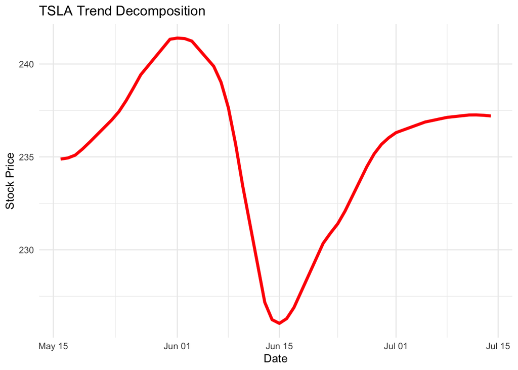

```r
##Tesla
loess_tsla<-loess(adjusted~as.numeric(date),data=tsla_data,span=tsla_optimal_span)
smooth_tsla<-predict(loess_tsla)
trend_decomp_tsla_plot<-tsla_data|>ggplot(aes(x=date))+geom_line(aes(y=smooth_tsla),color="red",linewidth=1.4) +
                                   labs(title="TSLA Trend Decomposition",x="Date",y="Stock Price") +
                                   theme_minimal()
trend_decomp_tsla_plot
```

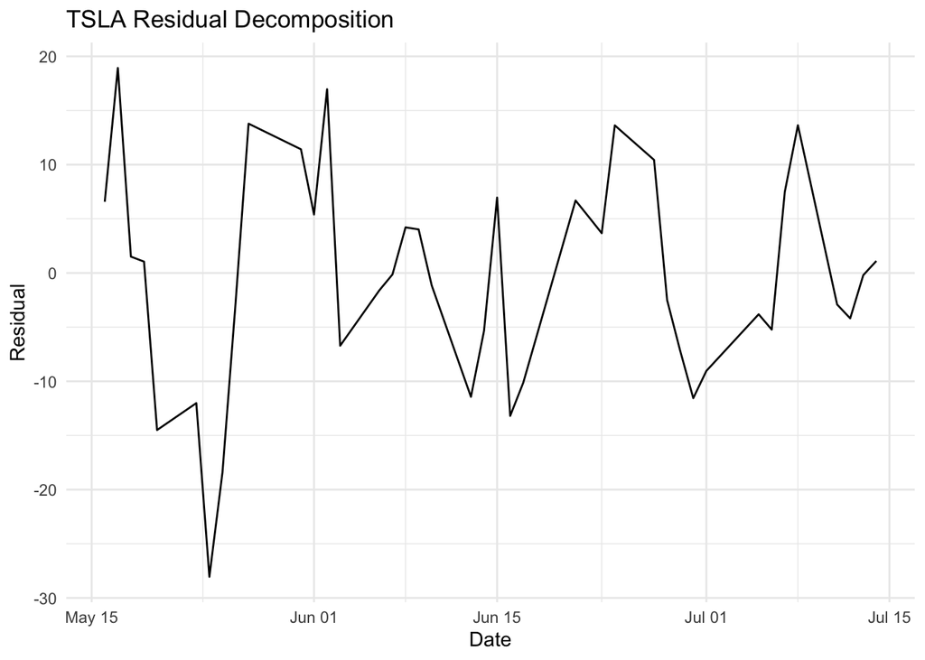

```r
tsla_data$residual_decomp<-residuals(loess_tsla)
residual_decomp_tsla_plot<-tsla_data|>ggplot(aes(x=date,y=residual_decomp))+geom_line() +
                                      labs(title="TSLA Residual Decomposition",x="Date",y="Residual") +
                                      theme_minimal()
residual_decomp_tsla_plot
```

```r
tsla_data
```

```
## # A tibble: 41 × 10
##    symbol date        open  high   low close    volume adjusted date_times
##    <chr>  <date>     <dbl> <dbl> <dbl> <dbl>     <dbl>    <dbl>      <dbl>
##  1 TSLA   2022-05-16  256.  257.  240.  241.  86098500     241.      19128
##  2 TSLA   2022-05-17  249.  255.  243.  254.  80236200     254.      19129
##  3 TSLA   2022-05-18  248.  254.  234.  237.  87811800     237.      19130
##  4 TSLA   2022-05-19  236.  245.  231.  236.  90296700     236.      19131
##  5 TSLA   2022-05-20  238.  241.  211   221. 144973200     221.      19132
##  6 TSLA   2022-05-23  218.  227.  213.  225.  88903500     225.      19135
##  7 TSLA   2022-05-24  218.  218.  207.  209.  89092500     209.      19136
##  8 TSLA   2022-05-25  208.  223.  208.  220.  92139300     220.      19137
##  9 TSLA   2022-05-26  220.  240.  218.  236. 106003200     236.      19138
## 10 TSLA   2022-05-27  241.  253.  240.  253.  89295000     253.      19139
## # ℹ 31 more rows
## # ℹ 1 more variable: residual_decomp <dbl>
```

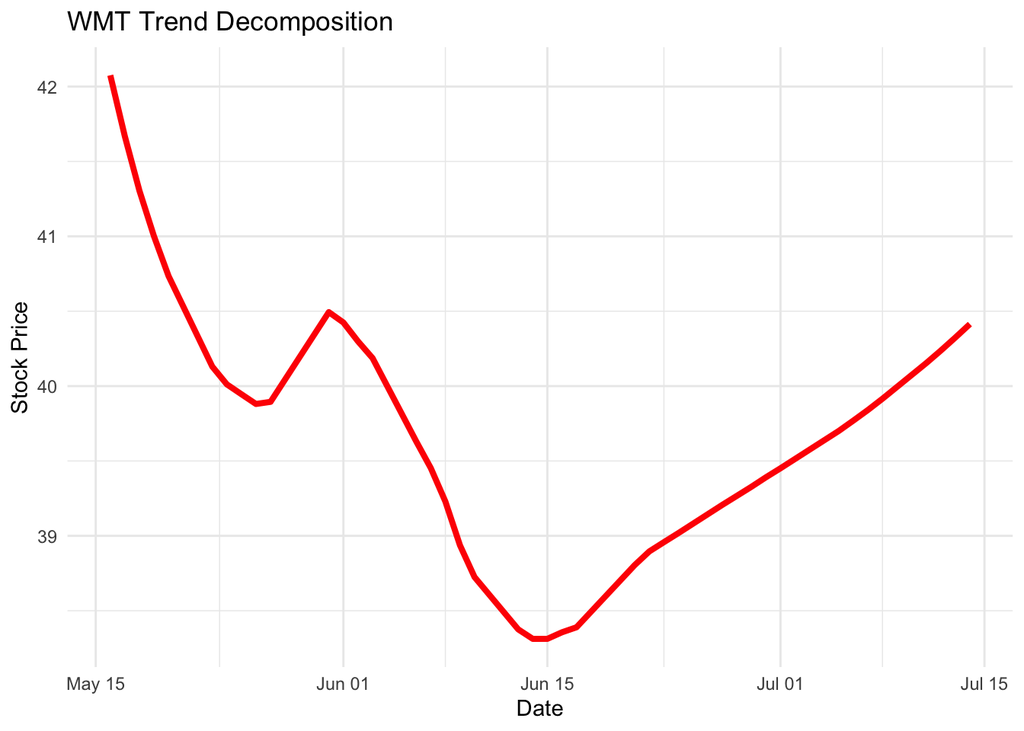

```r
##Walmart
loess_wmt<-loess(adjusted~as.numeric(date),data=wmt_data,span=wmt_optimal_span)
smooth_wmt<-predict(loess_wmt)
trend_decomp_wmt_plot<-wmt_data|>ggplot(aes(x=date))+geom_line(aes(y=smooth_wmt),color="red",linewidth=1.4 ) +
                                 labs(title="WMT Trend Decomposition",x="Date",y="Stock Price") +
                                 theme_minimal()
trend_decomp_wmt_plot
```

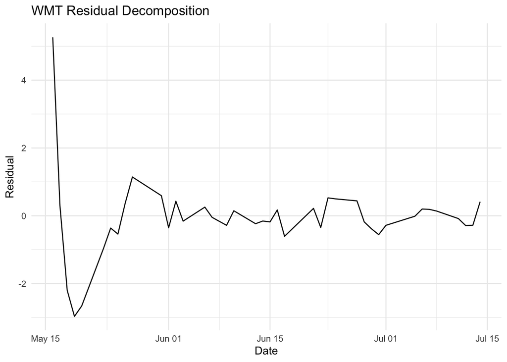

```r
wmt_data$residual_decomp<-residuals(loess_wmt)
residual_decomp_wmt_plot<-wmt_data|>ggplot(aes(x=date,y=residual_decomp))+geom_line() +
                                    labs(title="WMT Residual Decomposition",x="Date",y="Residual") +
                                    theme_minimal()
residual_decomp_wmt_plot
```

```r
wmt_data
```

```
## # A tibble: 41 × 10
##    symbol date        open  high   low close    volume adjusted date_times
##    <chr>  <date>     <dbl> <dbl> <dbl> <dbl>     <dbl>    <dbl>      <dbl>
##  1 WMT    2022-05-16  49.8  49.9  48.8  49.4  21449100     47.3      19128
##  2 WMT    2022-05-17  45.5  45.8  43.5  43.8 132940200     42.0      19129
##  3 WMT    2022-05-18  42.7  42.8  40.5  40.8 104253000     39.1      19130
##  4 WMT    2022-05-19  40.3  40.6  39.5  39.7  71008500     38.0      19131
##  5 WMT    2022-05-20  39.9  40.3  39.1  39.7  49356000     38.1      19132
##  6 WMT    2022-05-23  40.0  41.3  40.0  40.9  43680900     39.2      19135
##  7 WMT    2022-05-24  40.4  41.5  40.4  41.4  34584900     39.6      19136
##  8 WMT    2022-05-25  41.3  41.6  40.9  41.1  27121800     39.4      19137
##  9 WMT    2022-05-26  41.8  42.1  41.5  42    28197600     40.2      19138
## 10 WMT    2022-05-27  41.8  42.9  41.8  42.8  25299900     41.0      19139
## # ℹ 31 more rows
## # ℹ 1 more variable: residual_decomp <dbl>
```

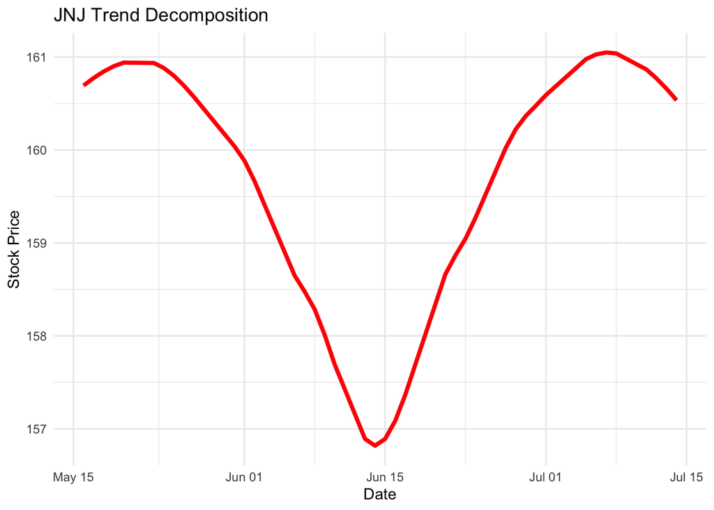

```r
##Johnson & Johnson
loess_jnj<-loess(adjusted~as.numeric(date),data=jnj_data,span=jnj_optimal_span)
smooth_jnj<-predict(loess_jnj)
trend_decomp_jnj_plot<-jnj_data|>ggplot(aes(x=date))+geom_line(aes(y=smooth_jnj),color="red",linewidth=1.4) +
                                 labs(title="JNJ Trend Decomposition",x="Date",y="Stock Price") +
                                 theme_minimal()
trend_decomp_jnj_plot
```

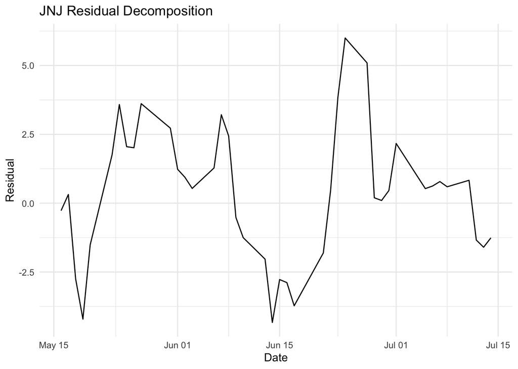

```r
jnj_data$residual_decomp<-residuals(loess_jnj)
residual_decomp_jnj_plot<-jnj_data|>ggplot(aes(x=date,y=residual_decomp))+geom_line() +
                          labs(title="JNJ Residual Decomposition",x="Date",y="Residual") +
                          theme_minimal()
residual_decomp_jnj_plot
```

```r
jnj_data
```

```
## # A tibble: 41 × 10
##    symbol date        open  high   low close  volume adjusted date_times
##    <chr>  <date>     <dbl> <dbl> <dbl> <dbl>   <dbl>    <dbl>      <dbl>
##  1 JNJ    2022-05-16  177.  179.  176.  178. 5516700     160.      19128
##  2 JNJ    2022-05-17  179.  180.  177.  179. 5751100     161.      19129
##  3 JNJ    2022-05-18  179.  179.  175.  176. 8608800     158.      19130
##  4 JNJ    2022-05-19  175.  175.  173.  174. 6874500     157.      19131
##  5 JNJ    2022-05-20  175.  177.  174.  177. 7522100     159.      19132
##  6 JNJ    2022-05-23  178.  180.  177.  179. 7040800     163.      19135
##  7 JNJ    2022-05-24  179.  182.  179.  181. 6419800     164.      19136
##  8 JNJ    2022-05-25  181.  182.  179.  180. 6558900     163.      19137
##  9 JNJ    2022-05-26  181   181   179.  179. 6897600     163.      19138
## 10 JNJ    2022-05-27  180.  181.  178.  181. 5853600     164.      19139
## # ℹ 31 more rows
## # ℹ 1 more variable: residual_decomp <dbl>
```

## Analysis of Trend and Residual Decompositions

Excluding Johnson & Johnson, the spread of stock prices and residuals after the Federal Reserve announcement saw a decline and any increases or decreases in stock prices were shallower. The trend for Johnson & Johnson is roughly symmetric before and after the announcement, which indicates that the volatility of the market remains roughly the same. All stocks experienced a declining trend in stock price prior to the announcement. Considering that a high range in stock prices would indicate more price swings, a lower range of residuals after the announcement makes sense as it indicates a more stable market with less unexpected changes in valuation. With the exception of Nvidia, all stocks seem to have a gradually rising trend in stock price roughly after the Federal Reserve announcement, which shows some recovery from the uncertainty cast by the May and June reports on inflation. This observation further supports the suggestion that reducing market uncertainty has more influence on market valuation than increasing uncertainty, as the effects of an initiative to counter inflation and assuring that future rate hikes will be smaller in magnitude seem to be more impactful than the uncertainty caused by interest rates.

## Returns, Mean Returns, Volatility, and 3-Day Rolling Volatility

Calculating returns, mean returns, volatility, and 3-day rolling volatility to compare for data analysis. For each stock, the returns, mean returns, and volatility are calculated prior to and after the Federal Reserve announcement to observe differences. The 3-day rolling volatility is calculated using the data from the previous 2 trading days and the current day, which means the first 3-day rolling volatility occurs on the third trading day.

```r
###Returns, Mean Returns

##Nvidia
nvda_data<-nvda_data|>mutate(returns=(adjusted-lag(adjusted))/lag(adjusted),
                             mean_returns=if_else(is.na(returns),NA_real_,cummean(replace_na(returns,0))))
nvda_mean_return_pre<-nvda_data|>filter(date<="2022-06-14",date>="2022-05-15")|>
                                 summarise(nvda_mean_return_pre = mean(returns,na.rm=TRUE))
nvda_mean_return_post<-nvda_data|>filter(date>="2022-06-16",date<="2022-07-15")|>
                                  summarise(nvda_mean_return_post = mean(returns,na.rm=TRUE))
nvda_mean_return_pre
```

```
## # A tibble: 1 × 1
##   nvda_mean_return_pre
##                  <dbl>
## 1             -0.00338
```

```r
nvda_mean_return_post
```

```
## # A tibble: 1 × 1
##   nvda_mean_return_post
##                   <dbl>
## 1              -0.00328
```

```r
##Amazon
amzn_data<-amzn_data|>mutate(returns=(adjusted-lag(adjusted))/lag(adjusted),
                             mean_returns=if_else(is.na(returns),NA_real_,cummean(replace_na(returns,0))))
amzn_mean_return_pre<-amzn_data|>filter(date<="2022-06-14",date>="2022-05-15")|>
                                 summarise(amzn_mean_return_pre = mean(returns,na.rm=TRUE))
amzn_mean_return_post<-amzn_data|>filter(date>="2022-06-16",date<="2022-07-15")|>
                                  summarise(amzn_mean_return_post = mean(returns,na.rm=TRUE))
amzn_mean_return_pre
```

```
## # A tibble: 1 × 1
##   amzn_mean_return_pre
##                  <dbl>
## 1             -0.00338
```

```r
amzn_mean_return_post
```

```
## # A tibble: 1 × 1
##   amzn_mean_return_post
##                   <dbl>
## 1               0.00178
```

```r
##Berkshire Hathaway
brkb_data<-brkb_data|>mutate(returns=(adjusted-lag(adjusted))/lag(adjusted),
                             mean_returns=if_else(is.na(returns),NA_real_,cummean(replace_na(returns,0))))
brkb_mean_return_pre<-brkb_data|>filter(date<="2022-06-14",date>="2022-05-15")|>
                                 summarise(brkb_mean_return_pre=mean(returns,na.rm=TRUE))
brkb_mean_return_post<-brkb_data|>filter(date>="2022-06-16",date<="2022-07-15")|>
                                  summarise(brkb_mean_return_post=mean(returns,na.rm=TRUE))
brkb_mean_return_pre
```

```
## # A tibble: 1 × 1
##   brkb_mean_return_pre
##                  <dbl>
## 1             -0.00525
```

```r
brkb_mean_return_post
```

```
## # A tibble: 1 × 1
##   brkb_mean_return_post
##                   <dbl>
## 1             -0.000747
```

```r
##Tesla
tsla_data<-tsla_data|>mutate(returns=(adjusted-lag(adjusted))/lag(adjusted),
                             mean_returns=if_else(is.na(returns),NA_real_,cummean(replace_na(returns,0))))
tsla_mean_return_pre<-tsla_data|>filter(date<="2022-06-14",date>="2022-05-15")|>
                                 summarise(tsla_mean_return_pre=mean(returns,na.rm=TRUE))
tsla_mean_return_post<-tsla_data|>filter(date>="2022-06-16",date<="2022-07-15")|>
                                  summarise(tsla_mean_return_post=mean(returns,na.rm=TRUE))
tsla_mean_return_pre
```

```
## # A tibble: 1 × 1
##   tsla_mean_return_pre
##                  <dbl>
## 1             -0.00323
```

```r
tsla_mean_return_post
```

```
## # A tibble: 1 × 1
##   tsla_mean_return_post
##                   <dbl>
## 1               0.00200
```

```r
##Walmart
wmt_data<-wmt_data|>mutate(returns=(adjusted-lag(adjusted))/lag(adjusted),
                           mean_returns=if_else(is.na(returns),NA_real_,cummean(replace_na(returns,0))))
wmt_mean_return_pre<-wmt_data|>filter(date<="2022-06-14",date>="2022-05-15")|>
                               summarise(wmt_mean_return_pre=mean(returns,na.rm=TRUE))
wmt_mean_return_post<-wmt_data|>filter(date>="2022-06-16",date<="2022-07-15")|>
                                summarise(wmt_mean_return_post=mean(returns,na.rm=TRUE))
wmt_mean_return_pre
```

```
## # A tibble: 1 × 1
##   wmt_mean_return_pre
##                 <dbl>
## 1             -0.0102
```

```r
wmt_mean_return_post
```

```
## # A tibble: 1 × 1
##   wmt_mean_return_post
##                  <dbl>
## 1              0.00368
```

```r
##Johnson & Johnson
jnj_data<-jnj_data|>mutate(returns=(adjusted-lag(adjusted))/lag(adjusted),
                           mean_returns=if_else(is.na(returns),NA_real_,cummean(replace_na(returns,0))))
jnj_mean_return_pre<-jnj_data|>filter(date<="2022-06-14",date>="2022-05-15")|>
                               summarise(jnj_mean_return_pre=mean(returns,na.rm=TRUE))
jnj_mean_return_post<-jnj_data|>filter(date>="2022-06-16",date<="2022-07-15")|>
                                summarise(jnj_mean_return_post=mean(returns,na.rm=TRUE))
jnj_mean_return_pre
```

```
## # A tibble: 1 × 1
##   jnj_mean_return_pre
##                 <dbl>
## 1            -0.00247
```

```r
jnj_mean_return_post
```

```
## # A tibble: 1 × 1
##   jnj_mean_return_post
##                  <dbl>
## 1              0.00180
```

```r
###Volatility

##Nvidia
nvda_volatility<-nvda_data|>summarise(nvda_volatility=sd(returns,na.rm=TRUE))
nvda_volatility_pre<-nvda_data|>filter(date<="2022-06-14",date>="2022-05-15")|>
                                summarise(nvda_volatility_pre=sd(returns,na.rm=TRUE))
nvda_volatility_post<-nvda_data|>filter(date>="2022-06-16",date<="2022-07-15")|>
                                 summarise(nvda_volatility_post=sd(returns,na.rm=TRUE))
nvda_volatility_pre
```

```
## # A tibble: 1 × 1
##   nvda_volatility_pre
##                 <dbl>
## 1              0.0438
```

```r
nvda_volatility_post
```

```
## # A tibble: 1 × 1
##   nvda_volatility_post
##                  <dbl>
## 1               0.0334
```

```r
##Amazon
amzn_volatility<-amzn_data|>summarise(amzn_volatility=sd(returns,na.rm=TRUE))
amzn_volatility_pre<-amzn_data|>filter(date<="2022-06-14",date>="2022-05-15")|>summarise(amzn_volatility_pre=sd(returns,na.rm=TRUE))
amzn_volatility_post<-amzn_data|>filter(date>="2022-06-16",date<="2022-07-15")|>summarise(amzn_volatility_post=sd(returns,na.rm=TRUE))
amzn_volatility_pre
```

```
## # A tibble: 1 × 1
##   amzn_volatility_pre
##                 <dbl>
## 1              0.0354
```

```r
amzn_volatility_post
```

```
## # A tibble: 1 × 1
##   amzn_volatility_post
##                  <dbl>
## 1               0.0273
```

```r
##Berkshire Hathaway
brkb_volatility<-brkb_data|>summarise(brkb_volatility=sd(returns,na.rm=TRUE))
brkb_volatility_pre<-brkb_data|>filter(date<="2022-06-14",date>="2022-05-15")|>summarise(brkb_volatility_pre=sd(returns,na.rm=TRUE))
brkb_volatility_post<-brkb_data|>filter(date>="2022-06-16",date<="2022-07-15")|>summarise(brkb_volatility_post=sd(returns,na.rm=TRUE))
brkb_volatility_pre
```

```
## # A tibble: 1 × 1
##   brkb_volatility_pre
##                 <dbl>
## 1              0.0166
```

```r
brkb_volatility_post
```

```
## # A tibble: 1 × 1
##   brkb_volatility_post
##                  <dbl>
## 1               0.0155
```

```r
##Tesla
tsla_volatility<-tsla_data|>summarise(volatility=sd(returns,na.rm=TRUE))
tsla_volatility_pre<-tsla_data|>filter(date<="2022-06-14",date>="2022-05-15")|>summarise(tsla_volatility_pre=sd(returns,na.rm=TRUE))
tsla_volatility_post<-tsla_data|>filter(date>="2022-06-16",date<="2022-07-15")|>summarise(tsla_volatility_post=sd(returns,na.rm=TRUE))
tsla_volatility_pre
```

```
## # A tibble: 1 × 1
##   tsla_volatility_pre
##                 <dbl>
## 1              0.0502
```

```r
tsla_volatility_post
```

```
## # A tibble: 1 × 1
##   tsla_volatility_post
##                  <dbl>
## 1               0.0413
```

```r
##Walmart
wmt_volatility<-wmt_data|>summarise(volatility=sd(returns,na.rm=TRUE))
wmt_volatility_pre<-wmt_data|>filter(date<="2022-06-14",date>="2022-05-15")|>summarise(wmt_volatility_pre=sd(returns,na.rm=TRUE))
wmt_volatility_post<-wmt_data|>filter(date>="2022-06-16",date<="2022-07-15")|>summarise(wmt_volatility_post=sd(returns,na.rm=TRUE))
wmt_volatility_pre
```

```
## # A tibble: 1 × 1
##   wmt_volatility_pre
##                <dbl>
## 1             0.0324
```

```r
wmt_volatility_post
```

```
## # A tibble: 1 × 1
##   wmt_volatility_post
##                 <dbl>
## 1              0.0128
```

```r
##Johnson & Johnson
jnj_volatility<-jnj_data|>summarise(volatility=sd(returns,na.rm=TRUE))
jnj_volatility_pre<-jnj_data|>filter(date<="2022-06-14",date>="2022-05-15")|>summarise(jnj_volatility_pre=sd(returns,na.rm=TRUE))
jnj_volatility_post<-jnj_data|>filter(date>="2022-06-16",date<="2022-07-15")|>summarise(jnj_volatility_post=sd(returns,na.rm=TRUE))
jnj_volatility_pre
```

```
## # A tibble: 1 × 1
##   jnj_volatility_pre
##                <dbl>
## 1             0.0114
```

```r
jnj_volatility_post
```

```
## # A tibble: 1 × 1
##   jnj_volatility_post
##                 <dbl>
## 1              0.0119
```

```r
###3-Day Rolling Volatility

##Nvidia
nvda_data<-nvda_data|>mutate(three_day_rolling_volatility=rollapply(returns,width=3,FUN=sd,na.rm=TRUE,fill=NA,align="right"))
nvda_data
```

```
## # A tibble: 41 × 13
##    symbol date        open  high   low close    volume adjusted date_times
##    <chr>  <date>     <dbl> <dbl> <dbl> <dbl>     <dbl>    <dbl>      <dbl>
##  1 NVDA   2022-05-16  17.5  17.8  17.1  17.3 521446000     17.2      19128
##  2 NVDA   2022-05-17  18.1  18.4  17.6  18.2 585830000     18.1      19129
##  3 NVDA   2022-05-18  17.7  18.1  16.9  16.9 545161000     16.9      19130
##  4 NVDA   2022-05-19  16.9  17.7  16.7  17.1 621310000     17.1      19131
##  5 NVDA   2022-05-20  17.3  17.4  15.8  16.7 739105000     16.7      19132
##  6 NVDA   2022-05-23  16.3  16.9  16.2  16.9 639889000     16.9      19135
##  7 NVDA   2022-05-24  16.5  16.6  15.8  16.2 588550000     16.1      19136
##  8 NVDA   2022-05-25  16.0  17.1  16    17.0 781132000     16.9      19137
##  9 NVDA   2022-05-26  16.0  18.1  16.0  17.9 996575000     17.8      19138
## 10 NVDA   2022-05-27  18.2  18.9  18.1  18.8 738379000     18.8      19139
## # ℹ 31 more rows
## # ℹ 4 more variables: residual_decomp <dbl>, returns <dbl>, mean_returns <dbl>,
## #   three_day_rolling_volatility <dbl>
```

```r
##Amazon
amzn_data<-amzn_data|>mutate(three_day_rolling_volatility=rollapply(returns,width=3,FUN=sd,na.rm=TRUE,fill=NA,align="right"))
amzn_data
```

```
## # A tibble: 41 × 13
##    symbol date        open  high   low close    volume adjusted date_times
##    <chr>  <date>     <dbl> <dbl> <dbl> <dbl>     <dbl>    <dbl>      <dbl>
##  1 AMZN   2022-05-16  113.  114.  110.  111.  74566000     111.      19128
##  2 AMZN   2022-05-17  113.  116.  111.  115.  76448000     115.      19129
##  3 AMZN   2022-05-18  111.  113.  106.  107. 108380000     107.      19130
##  4 AMZN   2022-05-19  106.  110.  106.  107.  88142000     107.      19131
##  5 AMZN   2022-05-20  110.  110.  105.  108.  99500000     108.      19132
##  6 AMZN   2022-05-23  108.  109.  104.  108. 107798000     108.      19135
##  7 AMZN   2022-05-24  104.  105.  101.  104. 102934000     104.      19136
##  8 AMZN   2022-05-25  104.  108.  104.  107.  93120000     107.      19137
##  9 AMZN   2022-05-26  108.  113.  107.  111.  93002000     111.      19138
## 10 AMZN   2022-05-27  114.  115.  113.  115.  93660000     115.      19139
## # ℹ 31 more rows
## # ℹ 4 more variables: residual_decomp <dbl>, returns <dbl>, mean_returns <dbl>,
## #   three_day_rolling_volatility <dbl>
```

```r
##Berkshire Hathaway
brkb_data<-brkb_data|>mutate(three_day_rolling_volatility=rollapply(returns,width=3,FUN=sd,na.rm=TRUE,fill=NA,align="right"))
brkb_data
```

```
## # A tibble: 41 × 13
##    symbol date        open  high   low close  volume adjusted date_times
##    <chr>  <date>     <dbl> <dbl> <dbl> <dbl>   <dbl>    <dbl>      <dbl>
##  1 BRK-B  2022-05-16  310.  312.  307.  309. 3697600     309.      19128
##  2 BRK-B  2022-05-17  315.  315.  312.  315. 4154200     315.      19129
##  3 BRK-B  2022-05-18  313.  314.  306.  307. 4417900     307.      19130
##  4 BRK-B  2022-05-19  304.  306.  301.  304. 4730100     304.      19131
##  5 BRK-B  2022-05-20  307.  307.  298.  304. 5517600     304.      19132
##  6 BRK-B  2022-05-23  307.  312.  307.  310. 4142100     310.      19135
##  7 BRK-B  2022-05-24  309.  310.  304.  309. 3657600     309.      19136
##  8 BRK-B  2022-05-25  309.  311.  306.  309. 3704800     309.      19137
##  9 BRK-B  2022-05-26  311.  314.  311.  312. 4472000     312.      19138
## 10 BRK-B  2022-05-27  315.  319.  314.  319. 4280100     319.      19139
## # ℹ 31 more rows
## # ℹ 4 more variables: residual_decomp <dbl>, returns <dbl>, mean_returns <dbl>,
## #   three_day_rolling_volatility <dbl>
```

```r
##Tesla
tsla_data<-tsla_data|>mutate(three_day_rolling_volatility=rollapply(returns,width=3,FUN=sd,na.rm=TRUE,fill=NA,align="right"))
tsla_data
```

```
## # A tibble: 41 × 13
##    symbol date        open  high   low close    volume adjusted date_times
##    <chr>  <date>     <dbl> <dbl> <dbl> <dbl>     <dbl>    <dbl>      <dbl>
##  1 TSLA   2022-05-16  256.  257.  240.  241.  86098500     241.      19128
##  2 TSLA   2022-05-17  249.  255.  243.  254.  80236200     254.      19129
##  3 TSLA   2022-05-18  248.  254.  234.  237.  87811800     237.      19130
##  4 TSLA   2022-05-19  236.  245.  231.  236.  90296700     236.      19131
##  5 TSLA   2022-05-20  238.  241.  211   221. 144973200     221.      19132
##  6 TSLA   2022-05-23  218.  227.  213.  225.  88903500     225.      19135
##  7 TSLA   2022-05-24  218.  218.  207.  209.  89092500     209.      19136
##  8 TSLA   2022-05-25  208.  223.  208.  220.  92139300     220.      19137
##  9 TSLA   2022-05-26  220.  240.  218.  236. 106003200     236.      19138
## 10 TSLA   2022-05-27  241.  253.  240.  253.  89295000     253.      19139
## # ℹ 31 more rows
## # ℹ 4 more variables: residual_decomp <dbl>, returns <dbl>, mean_returns <dbl>,
## #   three_day_rolling_volatility <dbl>
```

```r
##Walmart
wmt_data<-wmt_data|>mutate(three_day_rolling_volatility=rollapply(returns,width=3,FUN=sd,na.rm=TRUE,fill=NA,align="right"))
wmt_data
```

```
## # A tibble: 41 × 13
##    symbol date        open  high   low close    volume adjusted date_times
##    <chr>  <date>     <dbl> <dbl> <dbl> <dbl>     <dbl>    <dbl>      <dbl>
##  1 WMT    2022-05-16  49.8  49.9  48.8  49.4  21449100     47.3      19128
##  2 WMT    2022-05-17  45.5  45.8  43.5  43.8 132940200     42.0      19129
##  3 WMT    2022-05-18  42.7  42.8  40.5  40.8 104253000     39.1      19130
##  4 WMT    2022-05-19  40.3  40.6  39.5  39.7  71008500     38.0      19131
##  5 WMT    2022-05-20  39.9  40.3  39.1  39.7  49356000     38.1      19132
##  6 WMT    2022-05-23  40.0  41.3  40.0  40.9  43680900     39.2      19135
##  7 WMT    2022-05-24  40.4  41.5  40.4  41.4  34584900     39.6      19136
##  8 WMT    2022-05-25  41.3  41.6  40.9  41.1  27121800     39.4      19137
##  9 WMT    2022-05-26  41.8  42.1  41.5  42    28197600     40.2      19138
## 10 WMT    2022-05-27  41.8  42.9  41.8  42.8  25299900     41.0      19139
## # ℹ 31 more rows
## # ℹ 4 more variables: residual_decomp <dbl>, returns <dbl>, mean_returns <dbl>,
## #   three_day_rolling_volatility <dbl>
```

```r
##Johnson & Johnson
jnj_data<-jnj_data|>mutate(three_day_rolling_volatility=rollapply(returns,width=3,FUN=sd,na.rm=TRUE,fill=NA,align="right"))
jnj_data
```

```
## # A tibble: 41 × 13
##    symbol date        open  high   low close  volume adjusted date_times
##    <chr>  <date>     <dbl> <dbl> <dbl> <dbl>   <dbl>    <dbl>      <dbl>
##  1 JNJ    2022-05-16  177.  179.  176.  178. 5516700     160.      19128
##  2 JNJ    2022-05-17  179.  180.  177.  179. 5751100     161.      19129
##  3 JNJ    2022-05-18  179.  179.  175.  176. 8608800     158.      19130
##  4 JNJ    2022-05-19  175.  175.  173.  174. 6874500     157.      19131
##  5 JNJ    2022-05-20  175.  177.  174.  177. 7522100     159.      19132
##  6 JNJ    2022-05-23  178.  180.  177.  179. 7040800     163.      19135
##  7 JNJ    2022-05-24  179.  182.  179.  181. 6419800     164.      19136
##  8 JNJ    2022-05-25  181.  182.  179.  180. 6558900     163.      19137
##  9 JNJ    2022-05-26  181   181   179.  179. 6897600     163.      19138
## 10 JNJ    2022-05-27  180.  181.  178.  181. 5853600     164.      19139
## # ℹ 31 more rows
## # ℹ 4 more variables: residual_decomp <dbl>, returns <dbl>, mean_returns <dbl>,
## #   three_day_rolling_volatility <dbl>
```

## Analysis of Returns, Mean Returns, Volatility, and 3-Day Rolling Volatility

As the previous trend and residual decompositions have indicated, the volatility of all stocks, with the exception of Johnson & Johnson, have declined after the Federal Reserve announcement. Additionally, the mean return after the Federal Reserve announcement increased for all stocks. This observation further supports the suggestion that despite high interest rates putting corporate profits at risk, the indication that future rate hikes will not be as high and the initiative to counter inflation makes the future of the economy more predictable. With a more predictable economy, economic uncertainty is reduced and companies can further prepare for the future.

On the day of the Federal Reserve announcement, all stocks except for Walmart exhibited an increase in 3-day rolling volatility. This may be attributed to the increase in stock prices for most companies, which was not common in the days leading to the announcement.

## Correlation Heatmaps

Correlation heatmaps to compare correlation of returns, 3-day rolling volatilities, and residuals amongst stocks.

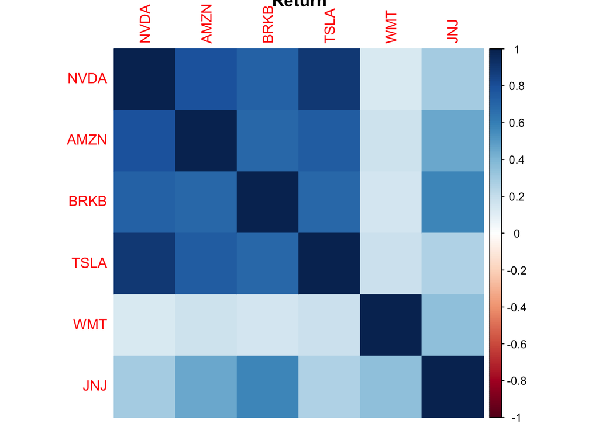

```r
##Returns

merged_returns<-inner_join(nvda_data,amzn_data,by='date',suffix=c('.nvda','.amzn'))|>
                inner_join(brkb_data,by="date",suffix=c(".amzn",".brkb"))|>
                inner_join(tsla_data,by='date',suffix=c(".brkb", ".tsla"))|>
                inner_join(wmt_data,by='date',suffix=c(".tsla", ".wmt"))|>
                inner_join(jnj_data,by='date',suffix=c(".wmt",".jnj"))|>
                select(date,returns.nvda,returns.amzn,returns.brkb,returns.tsla,returns.wmt,returns.jnj)|>
                rename(NVDA=returns.nvda,AMZN=returns.amzn,BRKB=returns.brkb,TSLA=returns.tsla,WMT=returns.wmt,JNJ=returns.jnj)
returns_correlations <- merged_returns|>select(-date)|>cor(use="complete.obs")
returns_corr_heatmap<-returns_correlations|>corrplot(method='color',main="Return")
```

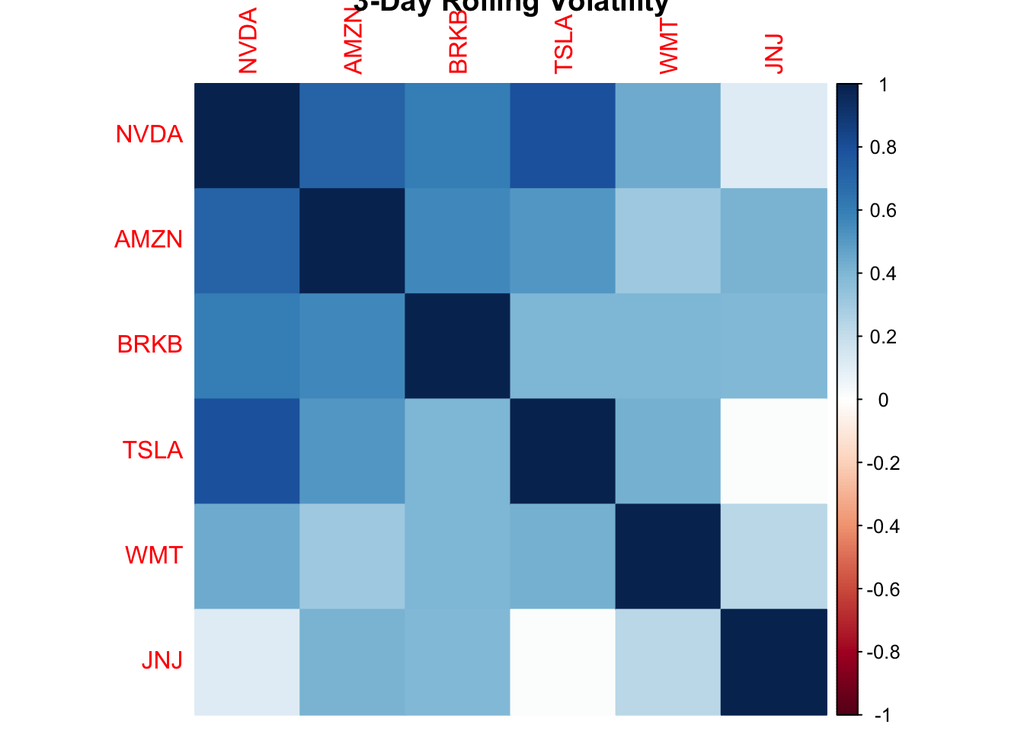

```r
##3-Day Rolling Volatilities
merged_rolling_volatilities<-inner_join(nvda_data,amzn_data,by='date',suffix=c('.nvda','.amzn'))|>
                             inner_join(brkb_data,by="date",suffix=c(".amzn",".brkb"))|>
                             inner_join(tsla_data,by='date',suffix=c(".brkb", ".tsla"))|>
                             inner_join(wmt_data,by='date',suffix=c(".tsla", ".wmt"))|>
                             inner_join(jnj_data,by='date',suffix=c(".wmt",".jnj"))|>
                             select(date,three_day_rolling_volatility.nvda,three_day_rolling_volatility.amzn,
                                    three_day_rolling_volatility.brkb,three_day_rolling_volatility.tsla,
                                    three_day_rolling_volatility.wmt,three_day_rolling_volatility.jnj)|>
                             rename(NVDA=three_day_rolling_volatility.nvda,AMZN=three_day_rolling_volatility.amzn,
                                    BRKB=three_day_rolling_volatility.brkb,TSLA=three_day_rolling_volatility.tsla,
                                    WMT=three_day_rolling_volatility.wmt,JNJ=three_day_rolling_volatility.jnj)
rolling_volatilities_correlations <- merged_rolling_volatilities|>select(-date)|>cor(use="complete.obs")
rolling_volatilities_corr_heatmap<-rolling_volatilities_correlations|>corrplot(method='color',
                                                                               main="3-Day Rolling Volatility")
```

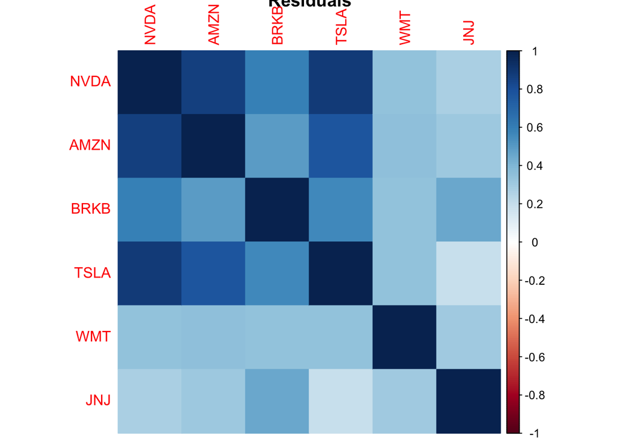

```r
##Residuals
merged_residuals<-inner_join(nvda_data,amzn_data,by='date',suffix=c('.nvda','.amzn'))|>
                  inner_join(brkb_data,by="date",suffix=c(".amzn",".brkb"))|>
                  inner_join(tsla_data,by='date',suffix=c(".brkb", ".tsla"))|>
                  inner_join(wmt_data,by='date',suffix=c(".tsla", ".wmt"))|>
                  inner_join(jnj_data,by='date',suffix=c(".wmt",".jnj"))|>
                  select(date,residual_decomp.nvda,residual_decomp.amzn,residual_decomp.brkb,
                         residual_decomp.tsla,residual_decomp.wmt,residual_decomp.jnj)|>
                  rename(NVDA=residual_decomp.nvda,AMZN=residual_decomp.amzn,BRKB=residual_decomp.brkb,
                         TSLA=residual_decomp.tsla,WMT=residual_decomp.wmt,JNJ=residual_decomp.jnj)
residuals_correlations<-merged_residuals|>select(-date)|>cor(use="complete.obs")
residuals_corr_heatmap<-residuals_correlations|>corrplot(method='color',main="Residuals")
```

## Boxplots

Boxplots showing the distrubution of returns, 3-day rolling volatilities, and residuals.

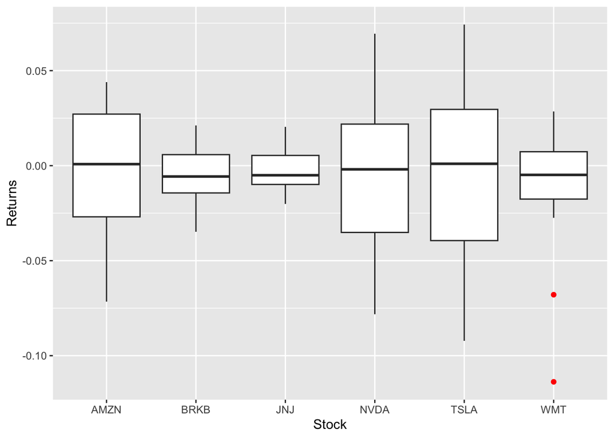

```r
##Returns

returns<-merged_returns|>select(-date)|>pivot_longer (cols=everything(),names_to="Stock",values_to="Returns")
returns_boxplot<-returns|>ggplot(aes(x=Stock,y=Returns))+geom_boxplot(outliers=TRUE,outlier.colour="red",
                                                                      na.rm=TRUE) +
                          labs(x="Stock",y="Returns")
returns_pre<-merged_returns|>filter(date<="2022-06-14",date>="2022-05-15")|>select(-date)|>
                             pivot_longer(cols=everything() ,names_to="Stock",values_to="Returns")
returns_pre_boxplot<-returns_pre|>ggplot(aes(x=Stock,y=Returns))+geom_boxplot(outliers=TRUE,outlier.colour="red",
                                                                              na.rm=TRUE) +
                                  labs(x="Stock",y="Returns")
returns_post<-merged_returns|>filter(date>="2022-06-16",date<="2022-07-15")|>select(-date)|>
                              pivot_longer(cols=everything(),names_to="Stock",values_to="Returns")
returns_post_boxplot<-returns_post|>ggplot(aes(x=Stock,y=Returns))+geom_boxplot(outliers=TRUE,outlier.colour="red",
                                                                                na.rm=TRUE) +
                                    labs(x="Stock",y="Returns")
returns_pre_boxplot
```

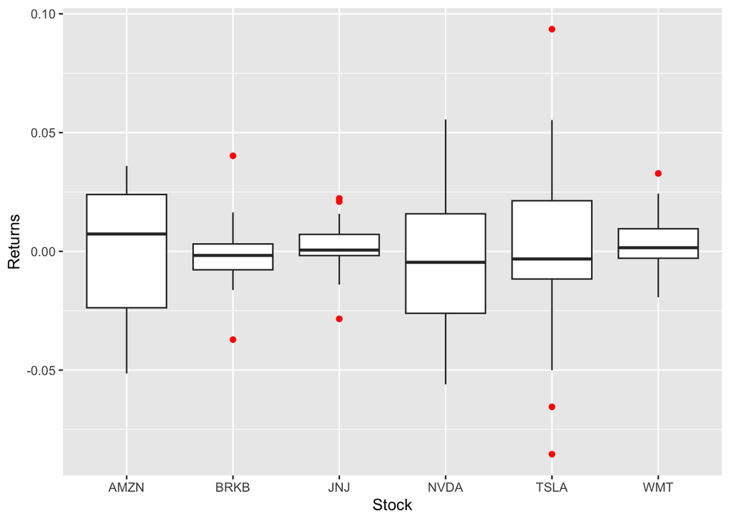

```r
returns_post_boxplot
```

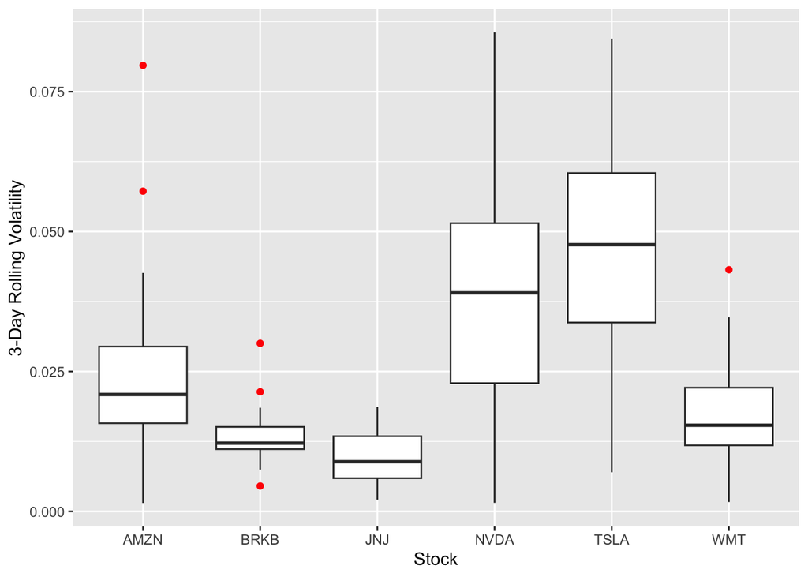

```r
##3-Day Rolling Volatilities

rolling_volatilities<-merged_rolling_volatilities|>
                      select(-date)|>
                      pivot_longer(cols=everything(),names_to="Stock",values_to="Three_Day_Rolling_Volatility")
rolling_volatilities_boxplot<-rolling_volatilities|>
                              ggplot(aes(x=Stock,y=Three_Day_Rolling_Volatility)) +
                              geom_boxplot(outliers=TRUE,outlier.colour="red",na.rm=TRUE) +
                              labs(x="Stock",y="3-Day Rolling Volatility")
rolling_volatilities_pre<-merged_rolling_volatilities|>
                          filter(date<="2022-06-14",date>="2022-05-15")|>
                          select(-date)|>
                          pivot_longer(cols=everything(),names_to="Stock",values_to="Three_Day_Rolling_Volatility")
rolling_volatilities_pre_boxplot<-rolling_volatilities_pre|>
                                  ggplot(aes(x=Stock,y=Three_Day_Rolling_Volatility)) +
                                  geom_boxplot(outliers=TRUE,outlier.colour="red",na.rm=TRUE) +
                                  labs(x="Stock",y="3-Day Rolling Volatility")
rolling_volatilities_post<-merged_rolling_volatilities|>
                           filter(date>="2022-06-16",date<="2022-07-15")|>
                           select(-date)|>
                           pivot_longer(cols=everything(),names_to="Stock",values_to="Three_Day_Rolling_Volatility")
rolling_volatilities_post_boxplot<-rolling_volatilities_post|>
                                   ggplot(aes(x=Stock,y=Three_Day_Rolling_Volatility)) +
                                   geom_boxplot(outliers=TRUE,outlier.colour="red",na.rm=TRUE) +
                                   labs(x="Stock",y="3-Day Rolling Volatility")
rolling_volatilities_pre_boxplot
```

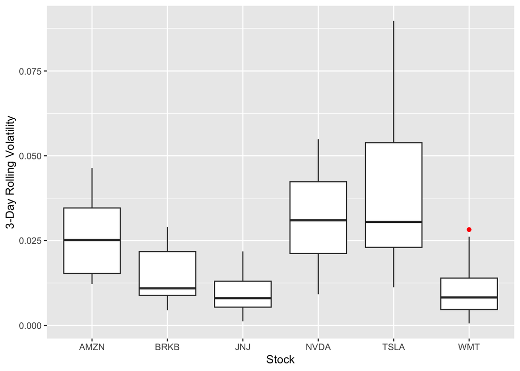

```r
rolling_volatilities_post_boxplot
```

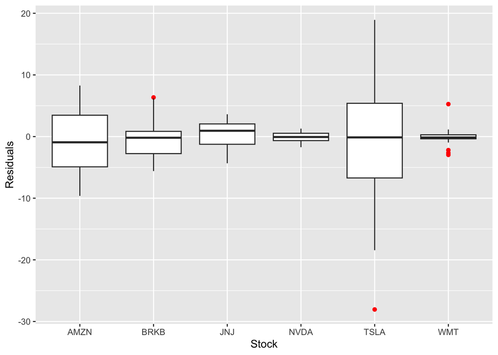

```r
##Residuals

residuals<-merged_residuals|>select(-date)|>pivot_longer (cols=everything(),names_to="Stock",
                                                          values_to="Residuals")
residuals_boxplot<-residuals|>ggplot(aes(x=Stock,y=Residuals)) +
                              geom_boxplot(outliers=TRUE,outlier.colour="red",na.rm=TRUE) +
                              labs(x="Stock",y="Residuals")
residuals_pre<-merged_residuals|>
               filter(date<="2022-06-14",date>="2022-05-15")|>
               select(-date)|>
               pivot_longer(cols=everything(),names_to="Stock",values_to="Residuals")
residuals_pre_boxplot<-residuals_pre|>
                       ggplot(aes(x=Stock,y=Residuals)) +
                       geom_boxplot(outliers=TRUE,outlier.colour="red",na.rm=TRUE) +
                       labs(x="Stock",y="Residuals")
residuals_post<-merged_residuals|>
                filter(date>="2022-06-16",date<="2022-07-15")|>
                select(-date)|>
                pivot_longer(cols=everything(),names_to="Stock",values_to="Residuals")
residuals_post_boxplot<-residuals_post|>
                        ggplot(aes(x=Stock,y=Residuals)) +
                        geom_boxplot(outliers=TRUE,outlier.colour="red",na.rm=TRUE) +
                        labs(x="Stock",y="Residuals")
residuals_pre_boxplot
```

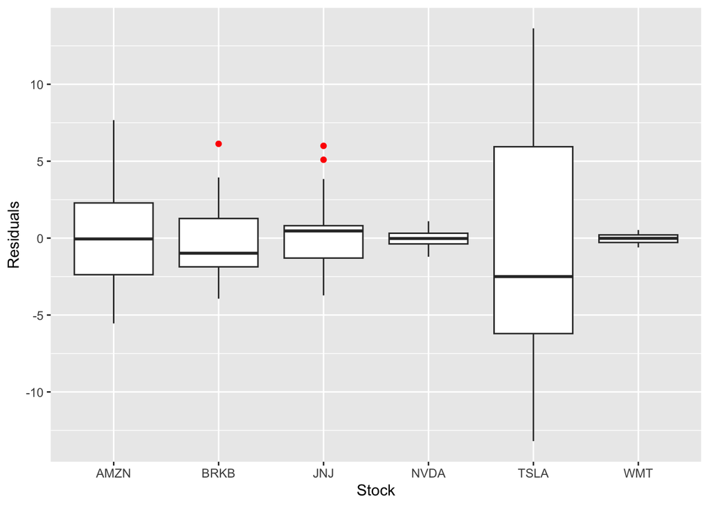

```r
residuals_post_boxplot
```

## Summary Statistics

Summary statistics tables included in addition to the boxplots to have a better sense of exact figures

```r
##Returns
returns_summary<-returns|>group_by(Stock)|>summarise(median=median(Returns,na.rm=TRUE),
                                                     Q1=quantile(Returns,.25,na.rm=TRUE),
                                                     Q3=quantile(Returns,.75,na.rm=TRUE),
                                                     min=min(Returns,na.rm=TRUE),
                                                     max=max(Returns,na.rm=TRUE),
                                                     IQR=Q3-Q1,
                                                     range=max-min)
returns_summary_pre<-returns_pre|>group_by(Stock)|>summarise(median=median(Returns,na.rm=TRUE),
                                                             Q1=quantile(Returns,.25,na.rm=TRUE),
                                                             Q3=quantile(Returns,.75,na.rm=TRUE),
                                                             min=min(Returns,na.rm=TRUE),
                                                             max=max(Returns,na.rm=TRUE),
                                                             IQR=Q3-Q1,
                                                             range=max-min)
returns_summary_post<-returns_post|>group_by(Stock)|>summarise(median=median(Returns,na.rm=TRUE),
                                                               Q1=quantile(Returns,.25,na.rm=TRUE),
                                                               Q3=quantile(Returns,.75,na.rm=TRUE),
                                                               min=min(Returns,na.rm=TRUE),
                                                               max=max(Returns,na.rm=TRUE),
                                                               IQR=Q3-Q1,
                                                               range=max-min)
returns_summary_pre
```

```
## # A tibble: 6 × 8
##   Stock    median       Q1      Q3     min    max    IQR  range
##   <chr>     <dbl>    <dbl>   <dbl>   <dbl>  <dbl>  <dbl>  <dbl>
## 1 AMZN   0.000806 -0.0269  0.0271  -0.0716 0.0440 0.0541 0.116
## 2 BRKB  -0.00572  -0.0144  0.00580 -0.0348 0.0212 0.0202 0.0559
## 3 JNJ   -0.00503  -0.00988 0.00539 -0.0201 0.0204 0.0153 0.0406
## 4 NVDA  -0.00193  -0.0351  0.0219  -0.0782 0.0694 0.0570 0.148
## 5 TSLA   0.000998 -0.0394  0.0296  -0.0922 0.0743 0.0690 0.166
## 6 WMT   -0.00486  -0.0176  0.00733 -0.114  0.0285 0.0249 0.142
```

```r
returns_summary_post
```

```
## # A tibble: 6 × 8
##   Stock    median       Q1      Q3     min    max     IQR  range
##   <chr>     <dbl>    <dbl>   <dbl>   <dbl>  <dbl>   <dbl>  <dbl>
## 1 AMZN   0.00731  -0.0238  0.0239  -0.0514 0.0360 0.0477  0.0874
## 2 BRKB  -0.00172  -0.00777 0.00312 -0.0372 0.0402 0.0109  0.0774
## 3 JNJ    0.000529 -0.00178 0.00713 -0.0284 0.0223 0.00891 0.0507
## 4 NVDA  -0.00462  -0.0261  0.0158  -0.0560 0.0555 0.0419  0.112
## 5 TSLA  -0.00320  -0.0117  0.0213  -0.0854 0.0935 0.0330  0.179
## 6 WMT    0.00152  -0.00291 0.00951 -0.0193 0.0328 0.0124  0.0521
```

```r
##Residuals
residuals_summary<-residuals|>group_by(Stock)|>summarise(median=median(Residuals),
                                                         Q1=quantile(Residuals,.25,na.rm=TRUE),
                                                         Q3=quantile(Residuals,.75,na.rm=TRUE),
                                                         min=min(Residuals),
                                                         max=max(Residuals),
                                                         IQR=Q3-Q1,
                                                         range=max-min)

residuals_summary_pre<-residuals_pre|>group_by(Stock)|>summarise(median=median(Residuals),
                                                                 Q1=quantile(Residuals,.25,na.rm=TRUE),
                                                                 Q3=quantile(Residuals,.75,na.rm=TRUE),
                                                                 min=min(Residuals),max=max(Residuals),
                                                                 IQR=Q3-Q1,
                                                                 range=max-min)

residuals_summary_post<-residuals_post|>group_by(Stock)|>summarise(median=median(Residuals),
                                                                   Q1=quantile(Residuals,.25,na.rm=TRUE),
                                                                   Q3=quantile(Residuals,.75,na.rm=TRUE),
                                                                   min=min(Residuals),
                                                                   max=max(Residuals),
                                                                   IQR=Q3-Q1,
                                                                   range=max-min)
residuals_summary_pre
```

```
## # A tibble: 6 × 8
##   Stock  median     Q1    Q3    min   max    IQR range
##   <chr>   <dbl>  <dbl> <dbl>  <dbl> <dbl>  <dbl> <dbl>
## 1 AMZN  -0.929  -4.91  3.46   -9.63  8.28  8.37  17.9
## 2 BRKB  -0.193  -2.77  0.845  -5.60  6.35  3.61  11.9
## 3 JNJ    0.941  -1.25  2.05   -4.33  3.61  3.30   7.95
## 4 NVDA  -0.0727 -0.655 0.536  -1.73  1.29  1.19   3.02
## 5 TSLA  -0.134  -6.72  5.40  -28.1  18.9  12.1   47.0
## 6 WMT   -0.158  -0.363 0.288  -2.97  5.26  0.650  8.23
```

```r
residuals_summary_post
```

```
## # A tibble: 6 × 8
##   Stock  median     Q1    Q3     min    max    IQR range
##   <chr>   <dbl>  <dbl> <dbl>   <dbl>  <dbl>  <dbl> <dbl>
## 1 AMZN  -0.0531 -2.38  2.29   -5.54   7.67   4.66  13.2
## 2 BRKB  -0.982  -1.87  1.28   -3.94   6.13   3.14  10.1
## 3 JNJ    0.466  -1.30  0.808  -3.72   6.00   2.11   9.72
## 4 NVDA  -0.0252 -0.376 0.316  -1.21   1.10   0.692  2.31
## 5 TSLA  -2.50   -6.21  5.94  -13.2   13.6   12.1   26.8
## 6 WMT   -0.0131 -0.284 0.208  -0.606  0.528  0.493  1.13
```

```r
##3-Day Rolling Volatility
rolling_volatilities_summary<-rolling_volatilities|>
                              group_by(Stock)|>
                              summarise(median=median(Three_Day_Rolling_Volatility,na.rm=TRUE),
                                        Q1=quantile(Three_Day_Rolling_Volatility,.25,na.rm=TRUE),
                                        Q3=quantile(Three_Day_Rolling_Volatility,.75,na.rm=TRUE),
                                        min=min(Three_Day_Rolling_Volatility,na.rm=TRUE),
                                        max=max(Three_Day_Rolling_Volatility,na.rm=TRUE),
                                        IQR=Q3-Q1,
                                        range=max-min)


rolling_volatilities_summary_pre<-rolling_volatilities_pre|>
                                  group_by(Stock)|>
                                  summarise(median=median(Three_Day_Rolling_Volatility,na.rm=TRUE),
                                            Q1=quantile(Three_Day_Rolling_Volatility,.25,na.rm=TRUE),
                                            Q3=quantile(Three_Day_Rolling_Volatility,.75,na.rm=TRUE),
                                            min=min(Three_Day_Rolling_Volatility,na.rm=TRUE),
                                            max=max(Three_Day_Rolling_Volatility,na.rm=TRUE),
                                            IQR=Q3-Q1,
                                            range=max-min)

rolling_volatilities_summary_post<-rolling_volatilities_post|>
                                   group_by(Stock)|>
                                   summarise(median=median(Three_Day_Rolling_Volatility,na.rm=TRUE),
                                             Q1=quantile(Three_Day_Rolling_Volatility,.25,na.rm=TRUE),
                                             Q3=quantile(Three_Day_Rolling_Volatility,.75,na.rm=TRUE),
                                             min=min(Three_Day_Rolling_Volatility),
                                             max=max(Three_Day_Rolling_Volatility),
                                             IQR=Q3-Q1,
                                             range=max-min)
rolling_volatilities_summary_pre
```

```
## # A tibble: 6 × 8
##   Stock  median      Q1     Q3     min    max     IQR  range
##   <chr>   <dbl>   <dbl>  <dbl>   <dbl>  <dbl>   <dbl>  <dbl>
## 1 AMZN  0.0209  0.0158  0.0295 0.00150 0.0797 0.0137  0.0782
## 2 BRKB  0.0122  0.0111  0.0151 0.00454 0.0300 0.00398 0.0255
## 3 JNJ   0.00887 0.00593 0.0134 0.00209 0.0187 0.00750 0.0166
## 4 NVDA  0.0390  0.0229  0.0515 0.00153 0.0856 0.0286  0.0841
## 5 TSLA  0.0477  0.0337  0.0604 0.00700 0.0844 0.0267  0.0775
## 6 WMT   0.0154  0.0118  0.0221 0.00167 0.0432 0.0103  0.0415
```

```r
rolling_volatilities_summary_post
```

```
## # A tibble: 6 × 8
##   Stock  median      Q1     Q3      min    max     IQR  range
##   <chr>   <dbl>   <dbl>  <dbl>    <dbl>  <dbl>   <dbl>  <dbl>
## 1 AMZN  0.0252  0.0153  0.0346 0.0122   0.0464 0.0193  0.0342
## 2 BRKB  0.0109  0.00886 0.0217 0.00449  0.0290 0.0129  0.0245
## 3 JNJ   0.00803 0.00539 0.0130 0.00120  0.0218 0.00765 0.0206
## 4 NVDA  0.0310  0.0213  0.0423 0.00918  0.0549 0.0211  0.0457
## 5 TSLA  0.0305  0.0230  0.0539 0.0112   0.0898 0.0308  0.0786
## 6 WMT   0.00824 0.00467 0.0140 0.000590 0.0282 0.00929 0.0277
```

## Analysis of Boxplot Statistics

Only Amazon exhibited an increase in median 3-day rolling volatility. However, its range declined by more than 50%, showing that its 3-day rolling volatilities are becoming more consistent after the announcement. Tesla and Johnson & Johnson experienced an increase in range of 3-day rolling volatilities. Such behaviour should not be too surprising for Johnson & Johnson, as the correlation heatmaps have portrayed that its stock prices do not behave similarly to the others. The change in Tesla’s range was the smallest of all stocks, which reduces chances that anything significant was causing this irregularity.

Only Johnson & Johnson saw an increase in range of residuals, which may portray more unusual irregularities than other companies that are experiencing less. Since it was suggested that the Federal Reserve announcement reduced economic uncertainty, having a lower range of residuals makes sense as the market should be more stabled. Johnson & Johnson seeing an increase in range further supports the suggestions that the effects of economic uncertainty on them is less severe and that they behave differently than the stocks that are more sensitive to these issues.